# Limits Day 2

## Warm-Up Questions!

```python
#hideme

import math

def f(x):
    return -1*x**2

def g(x):
    return x**2 + 3

def makeArrowY(ax,pos,function,direction):
    delta = 0.0001 if direction >= 0 else -0.01
    ax.arrow(pos,function(pos),delta,function(pos+delta)-function(pos),head_width=0.08,head_length=0.2, color="#1f77b4")

def makeArrowX(ax,pos,function,direction):
    delta = 0.0001 if direction >= 0 else -0.01
    ax.arrow(pos,function(pos),delta,function(pos+delta)-function(pos),head_width=0.1,head_length=0.05, color="#1f77b4")


fig = plt.figure(figsize=(7, 6))
ax = fig.add_subplot(111)
ax.set_title("$y = f(x)$", fontsize=20)

xleft = np.arange(-1, 1, 0.001)
xright = np.arange(1, 2, 0.001)
yright = f(xright)
yleft = g(xleft)
ax.plot(xleft, yleft)
ax.plot(xright, yright, color="#1f77b4")
#ax.yaxis.set_major_locator(ticker.MultipleLocator(1))

#ax.plot(1, 2, marker='o', linewidth=0, markersize=5, markerfacecolor="None",
         #markeredgecolor='black')


makeArrowY(ax, -1, g, -1)
makeArrowY(ax, 2, f, 1)


ax.grid(True)

ax.spines['left'].set_position('zero')
ax.spines['right'].set_color('none')
ax.spines['bottom'].set_position('zero')
ax.spines['top'].set_color('none')
ax.xaxis.set_ticks_position('bottom')
ax.yaxis.set_ticks_position('left')
```

What is $\displaystyle\lim_{x \rightarrow 1^-} f(x)$?

## Warm-Up Questions!

```python
#hideme

import math

def f(x):
    return -1*x**2

def g(x):
    return x**2 + 3

def makeArrowY(ax,pos,function,direction):
    delta = 0.0001 if direction >= 0 else -0.01
    ax.arrow(pos,function(pos),delta,function(pos+delta)-function(pos),head_width=0.08,head_length=0.2, color="#1f77b4")

def makeArrowX(ax,pos,function,direction):
    delta = 0.0001 if direction >= 0 else -0.01
    ax.arrow(pos,function(pos),delta,function(pos+delta)-function(pos),head_width=0.1,head_length=0.05, color="#1f77b4")


fig = plt.figure(figsize=(7, 6))
ax = fig.add_subplot(111)
ax.set_title("$y = f(x)$", fontsize=20)

xleft = np.arange(-1, 1, 0.001)
xright = np.arange(1, 2, 0.001)
yright = f(xright)
yleft = g(xleft)
ax.plot(xleft, yleft)
ax.plot(xright, yright, color="#1f77b4")
#ax.yaxis.set_major_locator(ticker.MultipleLocator(1))

#ax.plot(1, 2, marker='o', linewidth=0, markersize=5, markerfacecolor="None",
         #markeredgecolor='black')


makeArrowY(ax, -1, g, -1)
makeArrowY(ax, 2, f, 1)


ax.grid(True)

ax.spines['left'].set_position('zero')
ax.spines['right'].set_color('none')
ax.spines['bottom'].set_position('zero')
ax.spines['top'].set_color('none')
ax.xaxis.set_ticks_position('bottom')
ax.yaxis.set_ticks_position('left')
```

$\displaystyle\lim_{x \rightarrow 1^-} f(x) = 4$

## Warm-Up Questions!

```python
#hideme

import math

def f(x):
    return -1*x**2

def g(x):
    return x**2 + 3

def makeArrowY(ax,pos,function,direction):
    delta = 0.0001 if direction >= 0 else -0.01
    ax.arrow(pos,function(pos),delta,function(pos+delta)-function(pos),head_width=0.08,head_length=0.2, color="#1f77b4")

def makeArrowX(ax,pos,function,direction):
    delta = 0.0001 if direction >= 0 else -0.01
    ax.arrow(pos,function(pos),delta,function(pos+delta)-function(pos),head_width=0.1,head_length=0.05, color="#1f77b4")


fig = plt.figure(figsize=(7, 6))
ax = fig.add_subplot(111)
ax.set_title("$y = f(x)$", fontsize=20)

xleft = np.arange(-1, 1, 0.001)
xright = np.arange(1, 2, 0.001)
yright = f(xright)
yleft = g(xleft)
ax.plot(xleft, yleft)
ax.plot(xright, yright, color="#1f77b4")
#ax.yaxis.set_major_locator(ticker.MultipleLocator(1))

#ax.plot(1, 2, marker='o', linewidth=0, markersize=5, markerfacecolor="None",
         #markeredgecolor='black')


makeArrowY(ax, -1, g, -1)
makeArrowY(ax, 2, f, 1)


ax.grid(True)

ax.spines['left'].set_position('zero')
ax.spines['right'].set_color('none')
ax.spines['bottom'].set_position('zero')
ax.spines['top'].set_color('none')
ax.xaxis.set_ticks_position('bottom')
ax.yaxis.set_ticks_position('left')
```

What is $\displaystyle\lim_{x \rightarrow 1^+} f(x)$?

## Warm-Up Questions!

```python
#hideme

import math

def f(x):
    return -1*x**2

def g(x):
    return x**2 + 3

def makeArrowY(ax,pos,function,direction):
    delta = 0.0001 if direction >= 0 else -0.01
    ax.arrow(pos,function(pos),delta,function(pos+delta)-function(pos),head_width=0.08,head_length=0.2, color="#1f77b4")

def makeArrowX(ax,pos,function,direction):
    delta = 0.0001 if direction >= 0 else -0.01
    ax.arrow(pos,function(pos),delta,function(pos+delta)-function(pos),head_width=0.1,head_length=0.05, color="#1f77b4")


fig = plt.figure(figsize=(7, 6))
ax = fig.add_subplot(111)
ax.set_title("$y = f(x)$", fontsize=20)

xleft = np.arange(-1, 1, 0.001)
xright = np.arange(1, 2, 0.001)
yright = f(xright)
yleft = g(xleft)
ax.plot(xleft, yleft)
ax.plot(xright, yright, color="#1f77b4")
#ax.yaxis.set_major_locator(ticker.MultipleLocator(1))

#ax.plot(1, 2, marker='o', linewidth=0, markersize=5, markerfacecolor="None",
         #markeredgecolor='black')


makeArrowY(ax, -1, g, -1)
makeArrowY(ax, 2, f, 1)


ax.grid(True)

ax.spines['left'].set_position('zero')
ax.spines['right'].set_color('none')
ax.spines['bottom'].set_position('zero')
ax.spines['top'].set_color('none')
ax.xaxis.set_ticks_position('bottom')
ax.yaxis.set_ticks_position('left')
```

$\displaystyle\lim_{x \rightarrow 1^+} f(x) = -1$

## Warm-Up Questions!

```python
#hideme

import math

def f(x):
    return -1*x**2

def g(x):
    return x**2 + 3

def makeArrowY(ax,pos,function,direction):
    delta = 0.0001 if direction >= 0 else -0.01
    ax.arrow(pos,function(pos),delta,function(pos+delta)-function(pos),head_width=0.08,head_length=0.2, color="#1f77b4")

def makeArrowX(ax,pos,function,direction):
    delta = 0.0001 if direction >= 0 else -0.01
    ax.arrow(pos,function(pos),delta,function(pos+delta)-function(pos),head_width=0.1,head_length=0.05, color="#1f77b4")


fig = plt.figure(figsize=(7, 6))
ax = fig.add_subplot(111)
ax.set_title("$y = f(x)$", fontsize=20)

xleft = np.arange(-1, 1, 0.001)
xright = np.arange(1, 2, 0.001)
yright = f(xright)
yleft = g(xleft)
ax.plot(xleft, yleft)
ax.plot(xright, yright, color="#1f77b4")
#ax.yaxis.set_major_locator(ticker.MultipleLocator(1))

#ax.plot(1, 2, marker='o', linewidth=0, markersize=5, markerfacecolor="None",
         #markeredgecolor='black')


makeArrowY(ax, -1, g, -1)
makeArrowY(ax, 2, f, 1)


ax.grid(True)

ax.spines['left'].set_position('zero')
ax.spines['right'].set_color('none')
ax.spines['bottom'].set_position('zero')
ax.spines['top'].set_color('none')
ax.xaxis.set_ticks_position('bottom')
ax.yaxis.set_ticks_position('left')
```

What is $\displaystyle\lim_{x \rightarrow 1} f(x)$?

## Warm-Up Questions!

```python
#hideme

import math

def f(x):
    return -1*x**2

def g(x):
    return x**2 + 3

def makeArrowY(ax,pos,function,direction):
    delta = 0.0001 if direction >= 0 else -0.01
    ax.arrow(pos,function(pos),delta,function(pos+delta)-function(pos),head_width=0.08,head_length=0.2, color="#1f77b4")

def makeArrowX(ax,pos,function,direction):
    delta = 0.0001 if direction >= 0 else -0.01
    ax.arrow(pos,function(pos),delta,function(pos+delta)-function(pos),head_width=0.1,head_length=0.05, color="#1f77b4")


fig = plt.figure(figsize=(7, 6))
ax = fig.add_subplot(111)
ax.set_title("$y = f(x)$", fontsize=20)

xleft = np.arange(-1, 1, 0.001)
xright = np.arange(1, 2, 0.001)
yright = f(xright)
yleft = g(xleft)
ax.plot(xleft, yleft)
ax.plot(xright, yright, color="#1f77b4")
#ax.yaxis.set_major_locator(ticker.MultipleLocator(1))

#ax.plot(1, 2, marker='o', linewidth=0, markersize=5, markerfacecolor="None",
         #markeredgecolor='black')


makeArrowY(ax, -1, g, -1)
makeArrowY(ax, 2, f, 1)


ax.grid(True)

ax.spines['left'].set_position('zero')
ax.spines['right'].set_color('none')
ax.spines['bottom'].set_position('zero')
ax.spines['top'].set_color('none')
ax.xaxis.set_ticks_position('bottom')
ax.yaxis.set_ticks_position('left')
```

$\displaystyle\lim_{x \rightarrow 1} f(x)$ is undefined, because $\displaystyle\lim_{x \rightarrow 1^-} f(x) \neq \displaystyle\lim_{x \rightarrow 1^+} f(x)$

## A new problem: asymptotes

Consider the following function: $f(x) = \frac{1}{x^2}$

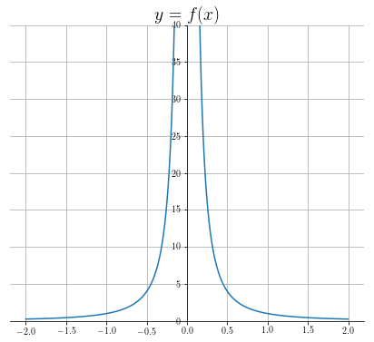

```python
#hideme

import math

def f(x):
    return 1/(x**2)



def makeArrowY(ax,pos,function,direction):
    delta = 0.0001 if direction >= 0 else -0.01
    ax.arrow(pos,function(pos),delta,function(pos+delta)-function(pos),head_width=0.08,head_length=0.2, color="#1f77b4")

def makeArrowX(ax,pos,function,direction):
    delta = 0.0001 if direction >= 0 else -0.01
    ax.arrow(pos,function(pos),delta,function(pos+delta)-function(pos),head_width=0.5,head_length=2, color="#1f77b4")


fig = plt.figure(figsize=(7, 6))
ax = fig.add_subplot(111)
ax.set_title("$y = f(x)$", fontsize=20)

xleft = np.arange(-2, -0.01, 0.001)
xright = np.arange(0.01, 2, 0.001)
yright = f(xright)
yleft = f(xleft)
ax.plot(xleft, yleft)
ax.plot(xright, yright, color="#1f77b4")
ax.set_ylim(0, 40)
#ax.yaxis.set_major_locator(ticker.MultipleLocator(1))

#ax.plot(1, 2, marker='o', linewidth=0, markersize=5, markerfacecolor="None",
         #markeredgecolor='black')


#makeArrowX(ax, -2, f, -1)
#makeArrowX(ax, 2, f, 1)


ax.grid(True)

ax.spines['left'].set_position('zero')
ax.spines['right'].set_color('none')
ax.spines['bottom'].set_position('zero')
ax.spines['top'].set_color('none')
ax.xaxis.set_ticks_position('bottom')
#ax.yaxis.set_ticks_position('left')()
```

At $x=0$, the function is undefined. But, there is not a clear value that it "approaches" there; how do we take the limit?

## A new problem: asymptotes

Consider the following function: $f(x) = \frac{1}{x^2}$

We say that $x = 0$ is a vertical *asymptote*. A vertical asymptote is a value at which the function "blows up" around.

\begin{equation} \lim_{x \rightarrow 0} \ \frac{1}{x^2} = \infty \end{equation}

## Concept Question

True or False: $\displaystyle\lim_{x \rightarrow 0} \ \frac{1}{x} = \infty$

False! $\displaystyle\lim_{x \rightarrow 0} \frac{1}{x} =$ undefined because

\begin{align} \lim_{x \rightarrow 0^-} \ \frac{1}{x} = -\infty && \lim_{x \rightarrow 0^+} \ \frac{1}{x} = \infty \end{align}

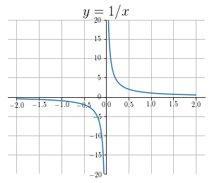

```python
#hideme

import math

def f(x):
    return 1/x



def makeArrowY(ax,pos,function,direction):
    delta = 0.0001 if direction >= 0 else -0.01
    ax.arrow(pos,function(pos),delta,function(pos+delta)-function(pos),head_width=0.08,head_length=0.2, color="#1f77b4")

def makeArrowX(ax,pos,function,direction):
    delta = 0.0001 if direction >= 0 else -0.01
    ax.arrow(pos,function(pos),delta,function(pos+delta)-function(pos),head_width=0.5,head_length=2, color="#1f77b4")


fig = plt.figure(figsize=(5, 4))
ax = fig.add_subplot(111)
ax.set_title("$y = 1/x$", fontsize=20)

xleft = np.arange(-2, -0.01, 0.001)
xright = np.arange(0.01, 2, 0.001)
yright = f(xright)
yleft = f(xleft)
ax.plot(xleft, yleft)
ax.plot(xright, yright, color="#1f77b4")
ax.set_ylim(-20, 20)
#ax.yaxis.set_major_locator(ticker.MultipleLocator(1))

#ax.plot(1, 2, marker='o', linewidth=0, markersize=5, markerfacecolor="None",
         #markeredgecolor='black')


#makeArrowX(ax, -2, f, -1)
#makeArrowX(ax, 2, f, 1)


ax.grid(True)

ax.spines['left'].set_position('zero')
ax.spines['right'].set_color('none')
ax.spines['bottom'].set_position('zero')
ax.spines['top'].set_color('none')
ax.xaxis.set_ticks_position('bottom')
#ax.yaxis.set_ticks_position('left')()
```

## Determining Asymptotes

If we are trying to evaluate $$\lim_{x \rightarrow a} \ f(x)$$ and $$f(a) = \frac{1}{0}$$ then we say that $a$ is a *vertical asymptote.*

If $\displaystyle\lim_{x \rightarrow a^-} f(x) = \displaystyle\lim_{x \rightarrow a^+} f(x)$ then $\displaystyle\lim_{x \rightarrow a} \ f(x) = \pm \infty$.

\begin{gather} \displaystyle\lim_{x \rightarrow a^-} f(x) = \displaystyle\lim_{x \rightarrow a^+} f(x) = \infty \rightarrow \displaystyle\lim_{x \rightarrow a} f(x) = \infty \\ \\ \displaystyle\lim_{x \rightarrow a^-} f(x) = \displaystyle\lim_{x \rightarrow a^+} f(x) = - \infty \rightarrow \displaystyle\lim_{x \rightarrow a} f(x) = - \infty \\ \\ \displaystyle\lim_{x \rightarrow a^-} f(x) \neq \displaystyle\lim_{x \rightarrow a^+} f(x) \rightarrow \displaystyle\lim_{x \rightarrow a} f(x) = \text{undefined} \end{gather}

*Note that $\frac{1}{0}$ is NOT an indeterminant form!*

## Constructing Graphs

In *groups of 3*, create 3 functions that have the desired limits

1. $\displaystyle\lim_{x \rightarrow 3} \ f(x) = \infty$
2. $\displaystyle\lim_{x \rightarrow 3^-} \ g(x) = -\infty$ and $\displaystyle\lim_{x \rightarrow 3^+} \ g(x) = \infty$
3. $\displaystyle\lim_{x \rightarrow 0^+} \ h(x) = -\infty$ and $h(x)$ is not a fraction

## Constructing Graphs Example 1

\begin{equation} \lim_{x \rightarrow 3} \ f(x) = \infty \end{equation}\begin{equation} f(x) = \frac{1}{(x-3)^2} \end{equation}

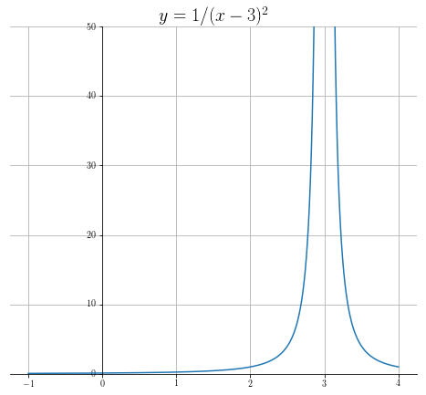

```python
#hideme

import math

def f(x):
    return 1/(x-3)**2



def makeArrowY(ax,pos,function,direction):
    delta = 0.0001 if direction >= 0 else -0.01
    ax.arrow(pos,function(pos),delta,function(pos+delta)-function(pos),head_width=0.08,head_length=0.2, color="#1f77b4")

def makeArrowX(ax,pos,function,direction):
    delta = 0.0001 if direction >= 0 else -0.01
    ax.arrow(pos,function(pos),delta,function(pos+delta)-function(pos),head_width=0.5,head_length=2, color="#1f77b4")


fig = plt.figure(figsize=(8, 7))
ax = fig.add_subplot(111)
ax.set_title("$y = 1/(x-3)^2$", fontsize=20)

xleft = np.arange(-1, 2.99, 0.001)
xright = np.arange(3.01, 4, 0.001)
yright = f(xright)
yleft = f(xleft)
ax.plot(xleft, yleft)
ax.plot(xright, yright, color="#1f77b4")
ax.set_ylim(0, 50)
#ax.yaxis.set_major_locator(ticker.MultipleLocator(1))

#ax.plot(1, 2, marker='o', linewidth=0, markersize=5, markerfacecolor="None",
         #markeredgecolor='black')


#makeArrowX(ax, -2, f, -1)
#makeArrowX(ax, 2, f, 1)


ax.grid(True)

ax.spines['left'].set_position('zero')
ax.spines['right'].set_color('none')
ax.spines['bottom'].set_position('zero')
ax.spines['top'].set_color('none')
ax.xaxis.set_ticks_position('bottom')
ax.yaxis.set_ticks_position('left')
```

## Constructing Graphs Example 2

\begin{align} \lim_{x \rightarrow 3^-} \ g(x) = -\infty && \lim_{x \rightarrow 3^+} \ g(x) = \infty \end{align}\begin{equation} g(x) = \frac{1}{(x-3)} \end{equation}

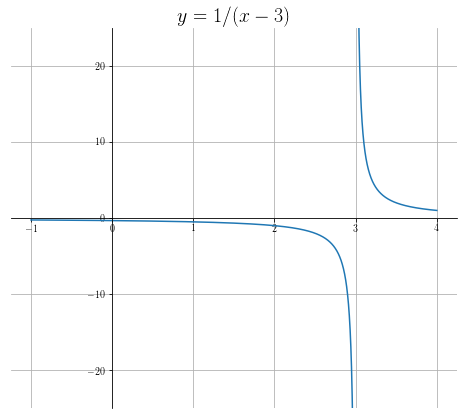

```python
#hideme

import math

def f(x):
    return 1/(x-3)



def makeArrowY(ax,pos,function,direction):
    delta = 0.0001 if direction >= 0 else -0.01
    ax.arrow(pos,function(pos),delta,function(pos+delta)-function(pos),head_width=0.08,head_length=0.2, color="#1f77b4")

def makeArrowX(ax,pos,function,direction):
    delta = 0.0001 if direction >= 0 else -0.01
    ax.arrow(pos,function(pos),delta,function(pos+delta)-function(pos),head_width=0.5,head_length=2, color="#1f77b4")


fig = plt.figure(figsize=(8, 7))
ax = fig.add_subplot(111)
ax.set_title("$y = 1/(x-3)$", fontsize=20)

xleft = np.arange(-1, 2.99, 0.001)
xright = np.arange(3.01, 4, 0.001)
yright = f(xright)
yleft = f(xleft)
ax.plot(xleft, yleft)
ax.plot(xright, yright, color="#1f77b4")
ax.set_ylim(-25, 25)
#ax.yaxis.set_major_locator(ticker.MultipleLocator(1))

#ax.plot(1, 2, marker='o', linewidth=0, markersize=5, markerfacecolor="None",
         #markeredgecolor='black')


#makeArrowX(ax, -2, f, -1)
#makeArrowX(ax, 2, f, 1)


ax.grid(True)

ax.spines['left'].set_position('zero')
ax.spines['right'].set_color('none')
ax.spines['bottom'].set_position('zero')
ax.spines['top'].set_color('none')
ax.xaxis.set_ticks_position('bottom')
ax.yaxis.set_ticks_position('left')
```

## Constructing Graphs

\begin{equation} \lim_{x \rightarrow 0^+} \ h(x) = -\infty \end{equation}\begin{equation} h(x) = \log(x) \end{equation}

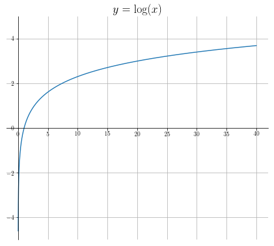

```python
#hideme

import math

def f(x):
    return np.log(x)



def makeArrowY(ax,pos,function,direction):
    delta = 0.0001 if direction >= 0 else -0.01
    ax.arrow(pos,function(pos),delta,function(pos+delta)-function(pos),head_width=0.08,head_length=0.2, color="#1f77b4")

def makeArrowX(ax,pos,function,direction):
    delta = 0.0001 if direction >= 0 else -0.01
    ax.arrow(pos,function(pos),delta,function(pos+delta)-function(pos),head_width=0.5,head_length=2, color="#1f77b4")


fig = plt.figure(figsize=(8, 7))
ax = fig.add_subplot(111)
ax.set_title("$y = \log(x)$", fontsize=20)

#xleft = np.arange(-4, 0.99, 0.001)
xright = np.arange(0.01, 40, 0.001)
yright = f(xright)
#yleft = f(xleft)
#ax.plot(xleft, yleft)
ax.plot(xright, yright, color="#1f77b4")
ax.set_ylim(-5, 5)
#ax.yaxis.set_major_locator(ticker.MultipleLocator(1))

#ax.plot(1, 2, marker='o', linewidth=0, markersize=5, markerfacecolor="None",
         #markeredgecolor='black')


#makeArrowX(ax, -2, f, -1)
#makeArrowX(ax, 2, f, 1)


ax.grid(True)

ax.spines['left'].set_position('zero')
ax.spines['right'].set_color('none')
ax.spines['bottom'].set_position('zero')
ax.spines['top'].set_color('none')
ax.xaxis.set_ticks_position('bottom')
ax.yaxis.set_ticks_position('left')
```

## A New Idea: What if $x \rightarrow \infty$?

Sometimes we care about understanding what happens to the value of a function for *arbitrarily large inputs*. Generally, one of two things will happen:

1. The function *diverges to $\pm \infty$*
2. The function *converges to some exact value*.

We'll look at some examples now.

## A simple diverging graph

\begin{equation} f(x) = x \end{equation}

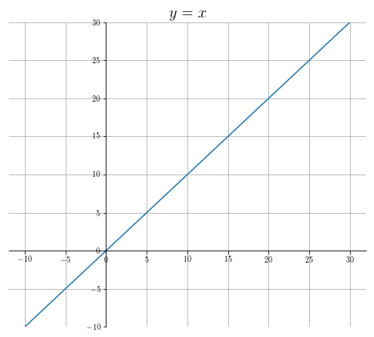

```python
#hideme

import math

def f(x):
    return x



def makeArrowY(ax,pos,function,direction):
    delta = 0.0001 if direction >= 0 else -0.01
    ax.arrow(pos,function(pos),delta,function(pos+delta)-function(pos),head_width=0.08,head_length=0.2, color="#1f77b4")

def makeArrowX(ax,pos,function,direction):
    delta = 0.0001 if direction >= 0 else -0.01
    ax.arrow(pos,function(pos),delta,function(pos+delta)-function(pos),head_width=0.5,head_length=2, color="#1f77b4")


fig = plt.figure(figsize=(8, 7))
ax = fig.add_subplot(111)
ax.set_title("$y = x$", fontsize=20)

#xleft = np.arange(-4, 0.99, 0.001)
xright = np.arange(-10, 30, 0.001)
yright = f(xright)
#yleft = f(xleft)
#ax.plot(xleft, yleft)
ax.plot(xright, yright, color="#1f77b4")
ax.set_ylim(-10, 30)
#ax.yaxis.set_major_locator(ticker.MultipleLocator(1))

#ax.plot(1, 2, marker='o', linewidth=0, markersize=5, markerfacecolor="None",
         #markeredgecolor='black')


#makeArrowX(ax, -2, f, -1)
#makeArrowX(ax, 2, f, 1)


ax.grid(True)

ax.spines['left'].set_position('zero')
ax.spines['right'].set_color('none')
ax.spines['bottom'].set_position('zero')
ax.spines['top'].set_color('none')
ax.xaxis.set_ticks_position('bottom')
ax.yaxis.set_ticks_position('left')
```

What happens as $x \rightarrow \infty$?

## A simple diverging graph

\begin{equation} f(x) = x \end{equation}

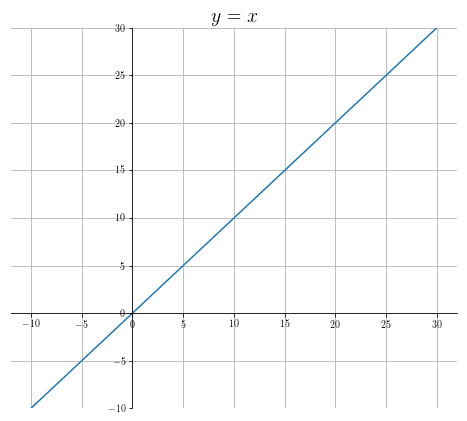

```python
#hideme

import math

def f(x):
    return x



def makeArrowY(ax,pos,function,direction):
    delta = 0.0001 if direction >= 0 else -0.01
    ax.arrow(pos,function(pos),delta,function(pos+delta)-function(pos),head_width=0.08,head_length=0.2, color="#1f77b4")

def makeArrowX(ax,pos,function,direction):
    delta = 0.0001 if direction >= 0 else -0.01
    ax.arrow(pos,function(pos),delta,function(pos+delta)-function(pos),head_width=0.5,head_length=2, color="#1f77b4")


fig = plt.figure(figsize=(8, 7))
ax = fig.add_subplot(111)
ax.set_title("$y = x$", fontsize=20)

#xleft = np.arange(-4, 0.99, 0.001)
xright = np.arange(-10, 30, 0.001)
yright = f(xright)
#yleft = f(xleft)
#ax.plot(xleft, yleft)
ax.plot(xright, yright, color="#1f77b4")
ax.set_ylim(-10, 30)
#ax.yaxis.set_major_locator(ticker.MultipleLocator(1))

#ax.plot(1, 2, marker='o', linewidth=0, markersize=5, markerfacecolor="None",
         #markeredgecolor='black')


#makeArrowX(ax, -2, f, -1)
#makeArrowX(ax, 2, f, 1)


ax.grid(True)

ax.spines['left'].set_position('zero')
ax.spines['right'].set_color('none')
ax.spines['bottom'].set_position('zero')
ax.spines['top'].set_color('none')
ax.xaxis.set_ticks_position('bottom')
ax.yaxis.set_ticks_position('left')
```

What happens as $x \rightarrow \infty$? $\displaystyle\lim_{x \rightarrow \infty} \ f(x) = \infty$!

## Some more diverging functions

What are some more functions that diverge as $x \rightarrow \infty$?

- $f(x) = x^2$
- $f(x) = \log(x)$
- $f(x) = e^x$

## Concept Question

True or False: If $\displaystyle\lim_{x \rightarrow \infty} \ f(x) = \infty$, then $\displaystyle\lim_{x \rightarrow \infty} \ c \cdot f(x) = \infty$ for any constant number $c$

True!: constants do not change the *behavior* of a function, only its specific values.

This makes it easy to evaluate limits with a bunch of constants in the function by ignoring them. I.e.

\begin{equation} \lim_{x \rightarrow \infty} \ c \cdot f(x) = c \cdot \lim_{x \rightarrow \infty} \ f(x) \end{equation}

## Rational Expressions

Consider the following limit

\begin{equation} \lim_{x \rightarrow \infty} \ \frac{x^3 +3x -10}{2x^2} \end{equation}

How do we think about evaluating this?

On top, as $x$ gets arbitrarily large, really only the $x^3$ term matters since it's much larger than the other two. So this limit should really be the same as

\begin{equation} \lim_{x \rightarrow \infty} \ \frac{x^3}{2x^2} \end{equation}

## Rational Expressions

\begin{equation} \lim_{x \rightarrow \infty} \ \frac{x^3}{2x^2} = \frac{1}{2} \lim_{x \rightarrow \infty} \ \frac{x^3}{x^2} \end{equation}

As $x$ grows arbitrarily large, $x^3$ grows *much, much, much faster* than $x^2$.

Since the numerator of the fraction is getter larger than the denominator, we get that

\begin{equation} \lim_{x \rightarrow \infty} \ \frac{x^3}{2x^2} = \infty \end{equation}

Thus,

\begin{equation} \lim_{x \rightarrow \infty} \ \frac{x^3+3x-10}{2x^2} = \infty \end{equation}

## What does *grows faster* mean?

Remember that we are letting $x$ get arbitrarily large. Let's look at a table of values

| $x$ | $x^3$ | $x^2$ | $x^3 - x^2$ |
| --- | --- | --- | --- |
| ... | ... | ... | ... |
| 10 | 1000 | 100 | 900 |
| 11 | 1331 | 121 | 1210 |
| 12 | 1728 | 144 | 1584 |
| 13 | 2197 | 169 | 2028 |
| 14 | 2744 | 196 | 2548 |
| ... | ... | ... | ... |

The difference between the numerator and denominator is increasing (at an increasing rate!), meaning the fraction gets larger and larger.

## Diverges?

Determine if each of the limits below diverges (does the limit $ = \infty$?)

\begin{gather} \lim_{x \rightarrow \infty} \frac{x^3}{x} \\ \\ \lim_{x \rightarrow \infty} \frac{\log(x)}{x} \\ \\ \lim_{x \rightarrow \infty} \frac{e^x}{x} \\ \\ \lim_{x \rightarrow \infty} \frac{x^3}{\log(x)} \\ \\ \lim_{x \rightarrow \infty} \frac{x^2 + 2x}{x^5\log(x)} \\ \\ \lim_{x \rightarrow \infty} \frac{x^2 + \log(x)}{x\log(x)} \end{gather}

## Diverges?

Determine if each of the limits below diverges (does the limit $ = \infty$?)

\begin{gather} \lim_{x \rightarrow \infty} \frac{x^3}{x} = \infty \\ \\ \lim_{x \rightarrow \infty} \frac{\log(x)}{x} \\ \\ \lim_{x \rightarrow \infty} \frac{e^x}{x} \\ \\ \lim_{x \rightarrow \infty} \frac{x^3}{\log(x)} \\ \\ \lim_{x \rightarrow \infty} \frac{x^2 + 2x}{x^5\log(x)} \\ \\ \lim_{x \rightarrow \infty} \frac{x^2 + \log(x)}{x\log(x)} \end{gather}

## Diverges?

Determine if each of the limits below diverges (does the limit $ = \infty$?)

\begin{gather} \lim_{x \rightarrow \infty} \frac{x^3}{x} = \infty \\ \\ \lim_{x \rightarrow \infty} \frac{\log(x)}{x} \neq \infty \\ \\ \lim_{x \rightarrow \infty} \frac{e^x}{x} \\ \\ \lim_{x \rightarrow \infty} \frac{x^3}{\log(x)} \\ \\ \lim_{x \rightarrow \infty} \frac{x^2 + 2x}{x^5\log(x)} \\ \\ \lim_{x \rightarrow \infty} \frac{x^2 + \log(x)}{x\log(x)} \end{gather}

## Diverges?

Determine if each of the limits below diverges (does the limit $ = \infty$?)

\begin{gather} \lim_{x \rightarrow \infty} \frac{x^3}{x} = \infty \\ \\ \lim_{x \rightarrow \infty} \frac{\log(x)}{x} \neq \infty \\ \\ \lim_{x \rightarrow \infty} \frac{e^x}{x} = \infty \\ \\ \lim_{x \rightarrow \infty} \frac{x^3}{\log(x)} \\ \\ \lim_{x \rightarrow \infty} \frac{x^2 + 2x}{x^5\log(x)} \\ \\ \lim_{x \rightarrow \infty} \frac{x^2 + \log(x)}{x\log(x)} \end{gather}

## Diverges?

Determine if each of the limits below diverges (does the limit $ = \infty$?)

\begin{gather} \lim_{x \rightarrow \infty} \frac{x^3}{x} = \infty \\ \\ \lim_{x \rightarrow \infty} \frac{\log(x)}{x} \neq \infty \\ \\ \lim_{x \rightarrow \infty} \frac{e^x}{x} = \infty \\ \\ \lim_{x \rightarrow \infty} \frac{x^3}{\log(x)} = \infty \\ \\ \lim_{x \rightarrow \infty} \frac{x^2 + 2x}{x^5\log(x)} \\ \\ \lim_{x \rightarrow \infty} \frac{x^2 + \log(x)}{x\log(x)} \end{gather}

## Diverges?

Determine if each of the limits below diverges (does the limit $ = \infty$?)

\begin{gather} \lim_{x \rightarrow \infty} \frac{x^3}{x} = \infty \\ \\ \lim_{x \rightarrow \infty} \frac{\log(x)}{x} \neq \infty \\ \\ \lim_{x \rightarrow \infty} \frac{e^x}{x} = \infty \\ \\ \lim_{x \rightarrow \infty} \frac{x^3}{\log(x)} = \infty \\ \\ \lim_{x \rightarrow \infty} \frac{x^2 + 2x}{x^5\log(x)} \neq \infty \\ \\ \lim_{x \rightarrow \infty} \frac{x^2 + \log(x)}{x\log(x)} \end{gather}

## Diverges?

Determine if each of the limits below diverges (does the limit $ = \infty$?)

\begin{gather} \lim_{x \rightarrow \infty} \frac{x^3}{x} = \infty \\ \\ \lim_{x \rightarrow \infty} \frac{\log(x)}{x} \neq \infty \\ \\ \lim_{x \rightarrow \infty} \frac{e^x}{x} = \infty \\ \\ \lim_{x \rightarrow \infty} \frac{x^3}{\log(x)} = \infty \\ \\ \lim_{x \rightarrow \infty} \frac{x^2 + 2x}{x^5\log(x)} \neq \infty \\ \\ \lim_{x \rightarrow \infty} \frac{x^2 + \log(x)}{x\log(x)} = \infty \end{gather}

## Wrapping Up

- If we are taking a limit of $\frac{p(x)}{q(x)}$, if $p(x)$ *grows faster* than $q(x)$, then the function diverges (the limit as $x \rightarrow \infty$ is $\infty$).
  - Some more examples include $\frac{x}{\log(x)}$ and $\frac{e^x}{x^c}$ for any value of $c$!
- Next time we will explore graphs that *converge* to a specific value as $x \rightarrow \infty$!